# Klasteranalüüsi praktikum

Laeme sisse vajalikud paketid.

```r
library(knitr)
library(dplyr)
library(kableExtra)
library(reshape2)
library(ggplot2)
library(data.table)
library(dendextend)
library(factoextra)
```

# Hierarhiline klasteranalüüs

Hierarhiline klasterdus on klastrite moodustamise meetod, mille käigus objektid on organiseeritud puutaoliseks struktuuriks e. dendrogrammiks. Hierarhilise klasterduse põhiidee on alustada igast objektist eraldi klastrina ja seejärel kombineerida need iteratiivselt suuremateks klastriteks nende sarnasuse alusel ehk samm-sammult hakatakse omavahel kokku panema kõige sarnasemaid objekte. Meid ei huvita ei alg- ega lõppseis vaid kogu küsimus peitub selles, et leida nn optimaalne klastrite arv. Hierarhiline klasterdusviis on mõeldav väikesemahuliste objektikogumite klasterdamisel, seda eeskätt tulemuste loetavuse huvides.

On kahte peamist tüüpi: ühendavad (*agglomerative*) ja lahutavad (*divisible*).

- **Ühendav** - nn alt-üles meetod, esimesel sammul (hierarhia esimesel tasemel) on iga objekt omaette klaster ja viimasel sammul (hierarhia viimasel tasemel) moodustavad kõik objektid ühise klastri. Igal hierarhia tasemel tehakse üks liigutus klastrite ühendamiseks teatud printsiibi kohaselt. Igal sammul (esimene välja arvatud) on eelmine klasterdus käesoleva klasterduse teatav liigendus. Analoogiliselt on iga klasterdus (viimane välja arvatud) omakorda järgneva teatav liigendus.
  - Tänases praktikumis kasutusel olev meetod. Võimalikud funktsioonid: `hclust` (paketist `stats`), `agnes` (paketist `cluster`).
  - Üldiselt arvutuslikult kallim meetod, eriti suuremate andmestike puhul. See lähenemisviis nõuab kõigi andmepunktide vahekauguste paarikaupa arvutamist, mis võib olla arvutuslikult kulukas.
  - Saab paremini hakkama erinditega, kuna neid saab lisada suurematesse klastritesse.
- **Lahutavad** - esimesel sammul on kõik objektid ühises klastris ja viimases igaüks eraldi. Tegevus igal sammul tähendab ühe klastri lahutamist. Millised klastrid konkreetsel sammul teisenevad, see oleneb klastritevahelise kauguse valikust, mis omakorda määrab klasterdusmeetodi.
  - Funktsioon `diana` paketist `cluster`.
  - Arvutuslikult odavam, kuna klastrite loomine nõuab ainult alamklastrite vaheliste kauguste arvutamist.
  - Võib luua alamklastreid erindite ümber, mis jällegi võib kaasa tuua ebaoptimaalsed klastrid.

Meeldetuletuseks: [erinevad ühendusmeetodid](https://samm.ut.ee/sissejuhatus-klasteranal%C3%BC%C3%BCsi).

# Klasteranalüüsi näide

> Laadige R-i majandusvabaduse indeksi andmestik (kaustas `data/`). Viige [majandusvabaduse indeks](https://www.heritage.org/index/)i aluseks olevate tunnustega (veerud 6-17) läbi hierarhiline klasteranalüüs erinevate meetoditega. **Kontrollige eelnevalt, kas tunnuseid oleks vaja standardiseerida.** (Standardiseerimist oleme käsitlenud esimesel nädalal erindite teema all, kus väärtuste erandlikkuse hindamiseks arvutasime z-skoorid.) Z-skooride arvutamiseks saab R-s kasutada käsku `scale` (vaja on ainult ühte argumenti). **Võrrelge tulemusi** - millised annavad kompaktseima või sisuliselt paremini tõlgendatava tulemuse? Milliste riikidega kokku kuulub Eesti? Kas see tundub sisuliselt loogiline?

## 1. Andmed

Loeme andmed sisse.

```r
econ <- read.csv2("data/econfreedom2.csv")
```

Vaatame, millised andmed andmestikus on.

Funktsioonid `kable`, `kable_styling` ja `scroll_box` on lisatud lihtsalt Rmarkdowniga loodud html-failis andmestiku lugejasõbralikumaks vormindamiseks.

```r
econ %>%
  kable(caption = "Tabel 1. Majandusvabaduse näitajad riigiti. Andmed: Heritage Foundation 2021.") %>%
  kable_styling("striped") %>%
  scroll_box(height = "500px", width = "100%")
```

Tabel 1. Majandusvabaduse näitajad riigiti. Andmed: Heritage Foundation 2021.

| Country.Name | Region | World.Rank | Region.Rank | X2021.Score | Property.Rights | Judical.Effectiveness | Government.Integrity | Tax.Burden | Gov.t.Spending | Fiscal.Health | Business.Freedom | Labor.Freedom | Monetary.Freedom | Trade.Freedom | Investment.Freedom | Financial.Freedom |
| --- | --- | --- | --- | --- | --- | --- | --- | --- | --- | --- | --- | --- | --- | --- | --- | --- |
| Afghanistan | Asia-Pacific | 146 | 33 | 53.0 | 30.3 | 25.7 | 29.1 | 91.1 | 76.1 | 99.9 | 53.9 | 59.9 | 80.8 | 68.6 | 10 | 10 |
| Albania | Europe | 66 | 35 | 65.2 | 46.1 | 22.8 | 40.6 | 89.0 | 74.6 | 86.6 | 66.1 | 51.6 | 82.0 | 82.8 | 70 | 70 |
| Algeria | Middle East and North Africa | 162 | 13 | 49.7 | 34.0 | 41.6 | 32.7 | 67.2 | 55.4 | 49.1 | 63.5 | 51.3 | 84.3 | 57.4 | 30 | 30 |
| Angola | Sub-Saharan Africa | 140 | 30 | 54.2 | 30.3 | 22.8 | 20.4 | 87.3 | 86.9 | 77.9 | 56.9 | 59.6 | 67.5 | 70.2 | 30 | 40 |
| Argentina | Americas | 148 | 26 | 52.7 | 46.1 | 45.7 | 54.0 | 70.4 | 52.8 | 38.4 | 59.5 | 46.3 | 41.9 | 62.6 | 55 | 60 |
| Armenia | Europe | 32 | 18 | 71.9 | 57.3 | 55.3 | 45.0 | 87.1 | 81.3 | 84.3 | 81.9 | 74.5 | 76.9 | 73.8 | 75 | 70 |
| Australia | Asia-Pacific | 3 | 3 | 82.4 | 81.5 | 90.0 | 89.8 | 62.6 | 58.1 | 88.7 | 87.4 | 84.1 | 86.7 | 89.8 | 80 | 90 |
| Austria | Europe | 25 | 13 | 73.9 | 86.8 | 83.5 | 84.8 | 45.7 | 29.1 | 90.0 | 72.6 | 68.4 | 81.7 | 84.0 | 90 | 70 |
| Azerbaijan | Europe | 38 | 23 | 70.1 | 67.9 | 55.8 | 46.8 | 88.1 | 65.2 | 99.4 | 80.5 | 65.9 | 73.2 | 68.0 | 70 | 60 |
| Bahamas | Americas | 70 | 13 | 64.6 | 48.1 | 45.7 | 47.5 | 97.1 | 87.6 | 72.7 | 70.4 | 70.0 | 77.0 | 49.0 | 50 | 60 |
| Bahrain | Middle East and North Africa | 40 | 4 | 69.9 | 71.5 | 65.8 | 64.4 | 100.0 | 67.1 | 0.0 | 76.7 | 71.4 | 82.8 | 83.6 | 75 | 80 |
| Bangladesh | Asia-Pacific | 120 | 25 | 56.5 | 38.0 | 35.4 | 27.7 | 84.0 | 93.8 | 66.3 | 55.6 | 68.8 | 69.9 | 63.4 | 45 | 30 |
| Barbados | Americas | 67 | 12 | 65.0 | 52.7 | 49.7 | 50.2 | 79.3 | 73.1 | 79.8 | 69.7 | 60.1 | 77.3 | 58.4 | 70 | 60 |
| Belarus | Europe | 95 | 43 | 61.0 | 58.6 | 40.4 | 39.8 | 92.9 | 55.5 | 96.5 | 75.9 | 75.7 | 70.2 | 76.0 | 30 | 20 |
| Belgium | Europe | 37 | 22 | 70.1 | 84.0 | 70.2 | 81.3 | 46.5 | 18.4 | 78.7 | 80.1 | 61.1 | 82.0 | 84.0 | 85 | 70 |
| Belize | Americas | 114 | 21 | 57.5 | 41.8 | 45.7 | 36.3 | 78.7 | 64.7 | 68.5 | 60.0 | 54.2 | 80.2 | 55.0 | 55 | 50 |
| Benin | Sub-Saharan Africa | 100 | 10 | 59.6 | 42.5 | 37.0 | 32.2 | 68.4 | 92.0 | 86.3 | 54.6 | 58.5 | 83.7 | 60.4 | 50 | 50 |
| Bhutan | Asia-Pacific | 109 | 22 | 58.3 | 62.6 | 45.7 | 55.0 | 82.2 | 71.6 | 70.2 | 67.3 | 79.6 | 74.3 | 40.8 | 20 | 30 |
| Bolivia | Americas | 172 | 30 | 42.7 | 18.7 | 11.0 | 25.9 | 85.3 | 58.4 | 13.4 | 58.4 | 53.4 | 71.0 | 61.6 | 15 | 40 |
| Bosnia and Herzegovina | Europe | 82 | 40 | 62.9 | 44.1 | 33.7 | 42.4 | 93.8 | 49.5 | 97.1 | 48.2 | 67.8 | 84.1 | 69.2 | 65 | 60 |
| Botswana | Sub-Saharan Africa | 51 | 3 | 67.6 | 58.6 | 50.8 | 48.8 | 87.4 | 68.2 | 74.8 | 68.4 | 68.2 | 74.1 | 77.4 | 65 | 70 |
| Brazil | Americas | 143 | 24 | 53.4 | 55.0 | 45.5 | 47.5 | 70.1 | 56.5 | 5.3 | 58.0 | 50.7 | 77.8 | 64.6 | 60 | 50 |
| Brunei Darussalam | Asia-Pacific | 57 | 11 | 66.6 | 61.1 | 62.3 | 47.5 | 92.3 | 67.6 | 20.0 | 83.6 | 90.9 | 74.7 | 84.6 | 65 | 50 |
| Bulgaria | Europe | 35 | 20 | 70.4 | 66.2 | 43.6 | 46.8 | 93.9 | 64.7 | 99.2 | 62.9 | 68.5 | 85.2 | 84.0 | 70 | 60 |
| Burkina Faso | Sub-Saharan Africa | 124 | 21 | 56.5 | 45.1 | 36.6 | 34.5 | 80.9 | 81.9 | 60.8 | 44.8 | 52.2 | 74.7 | 61.0 | 65 | 40 |
| Burma | Asia-Pacific | 135 | 30 | 55.2 | 37.2 | 19.7 | 32.7 | 87.2 | 87.1 | 81.9 | 60.0 | 64.3 | 72.5 | 70.0 | 30 | 20 |
| Burundi | Sub-Saharan Africa | 161 | 40 | 49.9 | 28.0 | 32.1 | 27.0 | 77.1 | 79.3 | 32.2 | 51.8 | 67.3 | 74.7 | 49.8 | 50 | 30 |
| Cambodia | Asia-Pacific | 118 | 24 | 57.3 | 39.9 | 23.2 | 17.0 | 89.1 | 84.3 | 98.3 | 30.9 | 62.6 | 75.1 | 66.6 | 50 | 50 |
| Cameroon | Sub-Saharan Africa | 144 | 32 | 53.4 | 38.3 | 27.2 | 21.0 | 74.8 | 89.0 | 79.9 | 43.9 | 49.9 | 81.2 | 55.2 | 30 | 50 |
| Canada | Americas | 9 | 1 | 77.9 | 84.5 | 73.3 | 87.9 | 76.0 | 49.8 | 84.2 | 81.4 | 72.4 | 76.1 | 88.8 | 80 | 80 |

[output cut: 154 more lines]

Andmestikus on meil riik, mis regiooni nad kuuluvad, järjekorra number maailmas, järjekorra number oma regioonis, majandusvabaduse indeks ja seejärel tunnused, mille põhjal on indeks koostatud.

Kontrollime ka, kui suur on andmelünkadega riikide osakaal andmestikus.

```r
# ridade arv andmestikus
nrow(econ)
```

```
## [1] 184
```

```r
# ridade arv andmestikus, kui eemaldada read puuduvate väärtustega
nrow(na.omit(econ))
```

```
## [1] 178
```

```r
# puuduvate väärtusteta ridade osakaal
nrow(na.omit(econ)) / nrow(econ)
```

```
## [1] 0.9673913
```

Neid ei ole palju, aga enne andmelünkadega riikide eemaldamist oleks hea vaadata, kas need vähesed riigid on mingi juhuslik kogum kõigist riikidest või kuidagi erandlik.

```r
econ %>%
  subset(!complete.cases(econ)) %>% # riigid, kus ei ole täielikud andmed
  pull(Country.Name)
```

```
## [1] "Iraq"          "Libya"         "Liechtenstein" "Somalia"
## [5] "Syria"         "Yemen"
```

Praktiliselt kõik need riigid on suuremal või vähemal määral sõjas. Seega pole tegu juhusliku valikuga riikidest, samas on selliste riikide puhul majandusvabadus teatud objektiivsetel asjaoludel tõsiselt häiritud ning nad ei ole niikuinii teiste riikidega samadel alustel võrreldavad.

Eemaldame andmelünkadega riigid.

```r
econ <- na.omit(econ)
```

Uurime tunnuste jaotuseid, et hinnata, kas tunnuseid oleks vaja standardiseerida. Standardiseerimine puudutab näiteks seda, et kas tunnused on erinevatel skaaladel või milline on tunnuste hajuvus.

`psych::describe` esitab kokkuvõtlikult mitmed näitajad tunnuste kohta:

```r
psych::describe(econ[6:17])
```

```
##                       vars   n  mean    sd median trimmed   mad  min   max
## Property.Rights          1 178 54.28 19.21  53.00   54.01 20.31  7.5  97.5
## Judical.Effectiveness    2 178 46.64 19.61  45.70   46.08 24.02  5.0  90.8
## Government.Integrity     3 178 46.08 20.61  40.60   44.04 15.79 11.5  97.2
## Tax.Burden               4 178 77.71 13.43  78.80   78.79 12.23  0.0 100.0
## Gov.t.Spending           5 178 67.35 22.66  71.25   70.47 21.87  0.0  96.0
## Fiscal.Health            6 178 72.45 28.60  81.95   77.02 19.79  0.0  99.9
## Business.Freedom         7 178 63.74 15.87  63.50   64.76 15.20  5.0  94.4
## Labor.Freedom            8 178 59.63 14.34  60.40   60.08 14.31  5.0  91.5
## Monetary.Freedom         9 178 74.96 12.57  77.45   77.00  6.67  0.0  86.9
## Trade.Freedom           10 178 70.87 12.79  71.20   72.01 13.49  0.0  95.0
## Investment.Freedom      11 178 56.88 21.33  60.00   58.58 22.24  0.0  95.0
## Financial.Freedom       12 178 48.37 18.87  50.00   48.61 14.83  0.0  90.0
##                       range  skew kurtosis   se
## Property.Rights        90.0  0.14    -0.74 1.44
## Judical.Effectiveness  85.8  0.22    -0.85 1.47
## Government.Integrity   85.7  0.83    -0.16 1.55
## Tax.Burden            100.0 -1.45     5.42 1.01
## Gov.t.Spending         96.0 -1.17     1.00 1.70
## Fiscal.Health          99.9 -1.24     0.35 2.14
## Business.Freedom       89.4 -0.68     0.72 1.19
## Labor.Freedom          86.5 -0.44     0.66 1.08
## Monetary.Freedom       86.9 -3.89    19.42 0.94
## Trade.Freedom          95.0 -1.38     4.70 0.96
## Investment.Freedom     95.0 -0.69    -0.06 1.60
## Financial.Freedom      90.0 -0.12    -0.62 1.41
```

**Mida eelnevast tabelist välja loete? Tunnused võiks standardiseerida, aga miks? Mida saame öelda tunnuste skaala ja hajuvuse kohta?**

Näiteks:

- Skaalad tunduvad võrreldavad -> maksimumväärtus tundub olevat 100 lähedal, miinimum 0 lähedal.
- Hajuvus:
  - Saame võrrelda standardhälbeid - kõige väiksemad standardhälbed on 12 juures ja kõrgemad 28 juures. Selline kahekordne erinevus standardhälvetes on päris suur erinevus. Tundub, et hajuvuse osas ei ole tunnused omavahel hästi võrreldavad.
  - MAD (*median absolute deviation*) - on sarnane näitaja standardhälbele, aga siin mitte ei opereerita keskmise ja standardhälbega, vaid mediaani ja erinevusega mediaanist
  - Infot saame ka asümmetria- (*skewness*) ja järskuskordajast (*kurtosis*) - nende puhul näitab 0-lähedane väärtus normaaljaotuse lähedast jaotust.
    - Asümeetriakordaja puhul tähendab see seda, et jaotus on asümmeetriline kummalegi poole. Normaaljaotuse puhul on nn talutav piir, kui kordajad jäävad vahemikku -1 kuni 1. Kui on suur asümmetriakordaja, siis võib ka eeldada, et tunnuse jaotuses võivad esineda erindid.
    - Erindite esinemist näitab ka järskuskordaja suur positiivne väärtus. Siin neid ka on, nt ühel juhul on järskuskordaja ~19, ent sellega kaasneb väike standardhälve - tunnuses valdav osa väärtustes on keskmise või muu väärtuse ümber ja on ka üks või rohkem erindeid, mis üldisest jaotusest hälbivad.

## 2. Standardiseerimine

Viime läbi standardiseerimise (arvutame z-skoorid) funktsiooniga `scale`.

Vaatame jaotusparameetreid:

```r
# teeme eraldi objekti tunnuste standardiseerimise jaoks
econ_st <- data.table::copy(econ)

# standardiseeritavad tunnused (arvulised)
econ_st[6:17] <- scale(econ[6:17])

psych::describe(econ_st[6:17])
```

```
##                       vars   n mean sd median trimmed  mad   min  max range
## Property.Rights          1 178    0  1  -0.07   -0.01 1.06 -2.43 2.25  4.68
## Judical.Effectiveness    2 178    0  1  -0.05   -0.03 1.22 -2.12 2.25  4.37
## Government.Integrity     3 178    0  1  -0.27   -0.10 0.77 -1.68 2.48  4.16
## Tax.Burden               4 178    0  1   0.08    0.08 0.91 -5.79 1.66  7.45
## Gov.t.Spending           5 178    0  1   0.17    0.14 0.96 -2.97 1.26  4.24
## Fiscal.Health            6 178    0  1   0.33    0.16 0.69 -2.53 0.96  3.49
## Business.Freedom         7 178    0  1  -0.01    0.06 0.96 -3.70 1.93  5.63
## Labor.Freedom            8 178    0  1   0.05    0.03 1.00 -3.81 2.22  6.03
## Monetary.Freedom         9 178    0  1   0.20    0.16 0.53 -5.96 0.95  6.91
## Trade.Freedom           10 178    0  1   0.03    0.09 1.06 -5.54 1.89  7.43
## Investment.Freedom      11 178    0  1   0.15    0.08 1.04 -2.67 1.79  4.45
## Financial.Freedom       12 178    0  1   0.09    0.01 0.79 -2.56 2.21  4.77
##                        skew kurtosis   se
## Property.Rights        0.14    -0.74 0.07
## Judical.Effectiveness  0.22    -0.85 0.07
## Government.Integrity   0.83    -0.16 0.07
## Tax.Burden            -1.45     5.42 0.07
## Gov.t.Spending        -1.17     1.00 0.07
## Fiscal.Health         -1.24     0.35 0.07
## Business.Freedom      -0.68     0.72 0.07
## Labor.Freedom         -0.44     0.66 0.07
## Monetary.Freedom      -3.89    19.42 0.07
## Trade.Freedom         -1.38     4.70 0.07
## Investment.Freedom    -0.69    -0.06 0.07
## Financial.Freedom     -0.12    -0.62 0.07
```

Nüüd näeme näiteks seda, et asümmetriakordaja ja järskuskordaja väärtused jäid täpselt samasuguseks. Muutusid keskmised ja standardhälbed, st see, mida tehakse z-skooride arvutamisega on see, et tunnuse jaotuse kuju jääb samaks, aga tunnuse väärtused nihkuvad ja skaala muutub. Erindite suhtes väga palju ei pruugi muutuda, aga need tunnused ise on omavahel paremini võrreldavad.

## 3. Kauguste arvutamine

Arvutame kauguste maatriksi, enne seda lisame riikide nimed reanimedeks, et hiljem oleks ka klasterduspuudel riikide nimed.

```r
rownames(econ_st) <- econ_st$Country.Name

d <- stats::dist(econ_st[6:17])
```

## 4. Klasterduspuud

Kui kaugused on arvutatud, siis järgmine samm on klasterduspuude tegemine.

### **Ühe seose meetod**

Kaugus kahe klastri vahel on nende klastrite lähimate elementide vaheline kaugus. Omavahel ühendatakse kõigi võimalike klastripaaride seast need klastrid, mille lähimad elemendid on teineteisele kõige lähemal. Praktikas on meetodile sageli omane ahelaefekt: objekte lisatakse järjest olemasolevatesse klastritesse juurde ja uut klastrit alustatakse vastumeelselt.

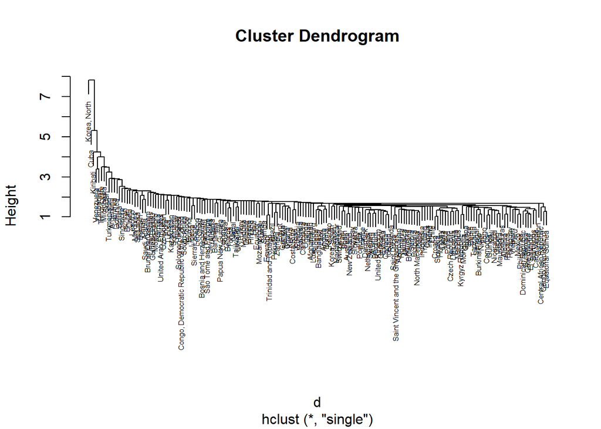

Joonis 1. Riikide klasterdus majandusvabadust kajastavate tunnuste alusel: klasterduspuu ühe seose meetodil.

```r
hclust(d, method = "single") %>%
  plot(cex = 0.5) # argumendiga cex saab x-teljel kirjasuurust määrata
```

- On näha ahelaefekt (kirjeldatud Toodingu raamatus lk 379-380)
- On näha erandlikud riigid, nt Põhja-Korea, Kuuba, Kiribati, Venezuela jne.

Klastrite uurimiseks, st eristuvate gruppide uurimiseks, kui me tahame väikest arvu klastreid (nt 4-5 oleks optimaalne), peaks hetkel joone tõmbama umbes 4 (y-teljel) juurest - nii tehes oleks, meil üks klaster, kus on pmst kõik maailma riigid; eraldi klastris Venezuela ja Zimbabwe; Kiribati, Kuuba ja Põhja-Korea kõik eraldi klastrites. Sisulises mõttes see ilmselt ei ole väga mõttekas.

### **Täieliku seose meetod**

Kaugus kahe klastri vahel on nende klastrite kaugeimate elementide vaheline kaugus. Omavahel ühendatakse kõigi võimalike klastripaaride seast need klastrid, mille kaugeimad elemendid on teineteisele kõige lähemal. Täieliku seose meetod arvestab ka objektide paigutust klastri sees ja seega kasutab ära klastrite ühendamisel konkreetsel sammul rohkem teavet kui ühe seose meetod.

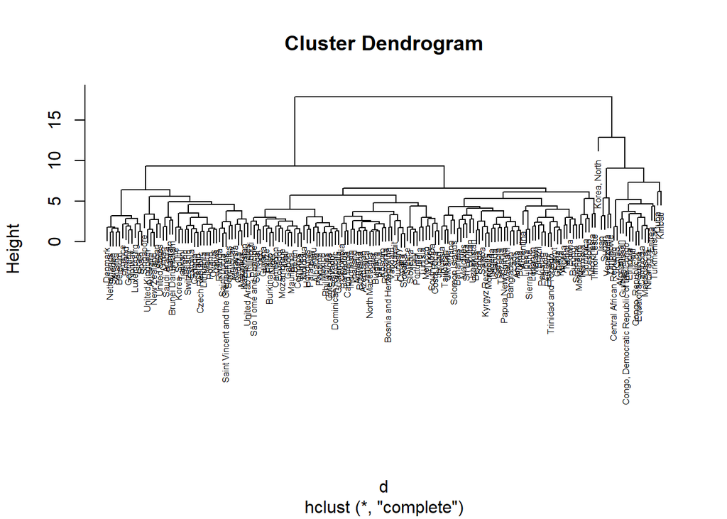

Joonis 2. Riikide klasterdus majandusvabadust kajastavate tunnuste alusel: klasterduspuu täieliku seose meetodil.

```r
hclust(d, method = "complete") %>%
  plot(cex = 0.5)
```

Juba veidi variatiivsem, aga Põhja-Korea oleks jälle eraldi, põhiosa riikidest ühes suures klastris.

### **Klastritevahelise keskmise kauguse meetod**

Kahe klastri vaheliseks kauguseks loetakse keskmine kaugus kõigis objektipaarides, mil üks paariline kuulub ühte ja teine teise klastrisse. Omavahel ühendatakse need klastrid, mille puhul selline keskmine kaugus on vähim.

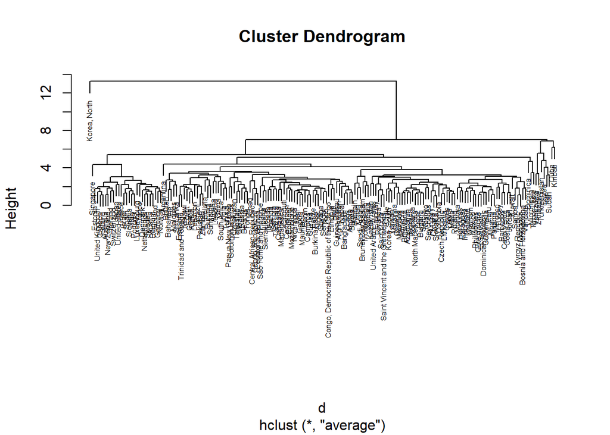

Joonis 3. Riikide klasterdus majandusvabadust kajastavate tunnuste alusel: klasterduspuu keskmise kauguse meetodil.

```r
hclust(d, method = "average") %>%
  plot(cex = 0.5)
```

Põhja-Korea on eraldi. Samuti on erandlikud riigid eraldi klastrites ja jällegi samuti üks suurem klaster.

### **Wardi meetod**

Wardi meetod on kujunenud praktikas hierarhilistest klasterdusmeetoditest soosituimaks ja seda peetakse heaks klastrite äratundjaks. Meetod erineb eelnevalt kirjeldatuist ja toetub klastreis arvutatud summaarsetele ruuthälvetele klastrikeskmise suhtes (klastrikeskmise määravad klasterdustunnuste keskmised). Omavahel ühendatakse need klastrid, mille puhul summaarse ruuthälbe kasv ühendklastris võrreldes klastritesiseste summaarsete ruuthälvete summaga on vähim. Wardi meetod eelistab omavahel ühendada lähendaste klastrikeskmistega klastreid. Kauguseks selle meetodi korral võetakse eukleidiline ruutkaugus (toetub ruuthälbeile).

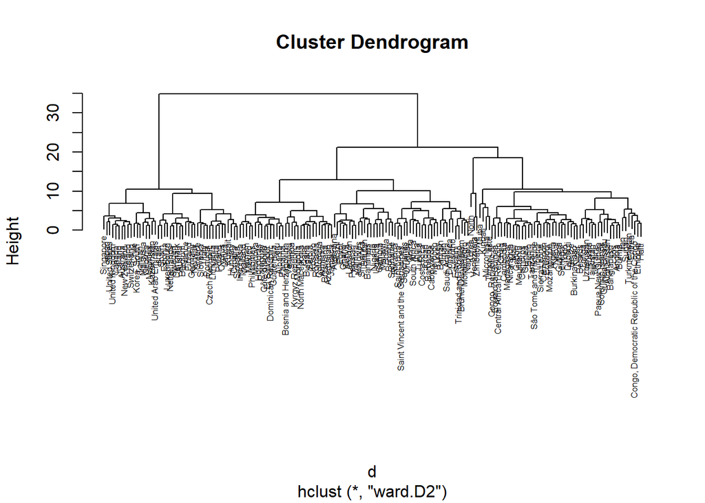

Joonis 4. Riikide klasterdus majandusvabadust kajastavate tunnuste alusel: klasterduspuu Wardi meetodil.

```r
hclust(d, method = "ward.D2") %>%
  plot(cex = 0.5)
```

Selgelt eristub 4 klastrit.

## 5. Tutvume klastritega

Uurime klastreid lähemalt. Loome klastrikuuluvuse tunnuse `ward4` funktsiooniga `cutree`, millega anname R-le teada, et soovime nelja klastrit. Iga riik saab väärtuse oma klastrikuuluvuse kohta.

```r
econ_st$ward4 <- hclust(d, method = "ward.D2") %>%
  cutree(4)
```

Vaatame, millisesse klastrisse kuulub Eesti.

```r
econ_st %>%
  subset(Country.Name == "Estonia") %>%
  pull(ward4)
```

```
## [1] 3
```

Millises seltskonnas me oma majandusvabaduse näitajate poolest oleme?

```r
econ_st %>%
  subset(ward4 == 3) %>%
  pull(Country.Name)
```

```
##  [1] "Australia"            "Austria"              "Belgium"
##  [4] "Canada"               "Chile"                "Croatia"
##  [7] "Cyprus"               "Czech Republic"       "Denmark"
## [10] "Estonia"              "Finland"              "France"
## [13] "Georgia"              "Germany"              "Greece"
## [16] "Hungary"              "Iceland"              "Ireland"
## [19] "Israel"               "Italy"                "Japan"
## [22] "Kazakhstan"           "Korea, South"         "Kuwait"
## [25] "Latvia"               "Lithuania"            "Luxembourg"
## [28] "Malaysia"             "Malta"                "Mauritius"
## [31] "Netherlands"          "New Zealand"          "Norway"
## [34] "Poland"               "Portugal"             "Singapore"
## [37] "Slovakia"             "Slovenia"             "Spain"
## [40] "Sweden"               "Switzerland"          "Taiwan "
## [43] "United Arab Emirates" "United Kingdom"       "United States"
```

Pole paha. Tundub, et heas (st parimas võimalikus) seltskonnas, aga kontrollime järele. Millised on nendes neljas klastris indeksi keskmised väärtused ja järjekorra numbri mediaan väärtus?

```r
econ_st %>%
  group_by(ward4) %>%
  summarise(indeksi_keskm = mean(X2021.Score),
            jrjk_mediaan = median(World.Rank))
```

```
## # A tibble: 4 × 3
##   ward4 indeksi_keskm jrjk_mediaan
##   <int>         <dbl>        <dbl>
## 1     1          53.3        134.
## 2     2          61.8         82.5
## 3     3          73.8         23
## 4     4          23.1        177
```

Peab paika. Millised riigid moodustavad siis omaette ülejäänud klastrid?

```r
print('1.klaster:')
```

```
## [1] "1.klaster:"
```

```r
econ_st %>%
  subset(ward4 == 1) %>%
  pull(Country.Name)
```

```
##  [1] "Afghanistan"
##  [2] "Algeria"
##  [3] "Angola"
##  [4] "Bangladesh"
##  [5] "Belarus"
##  [6] "Belize"
##  [7] "Benin"
##  [8] "Burkina Faso"
##  [9] "Burma"
## [10] "Cambodia"
## [11] "Cameroon"
## [12] "Central African Republic"
## [13] "Chad"
## [14] "Comoros"
## [15] "Congo, Democratic Republic of the Congo"
```

[output cut: 39 more lines]

```r
print('2.klaster:')
```

```
## [1] "2.klaster:"
```

```r
econ_st %>%
  subset(ward4 == 2) %>%
  pull(Country.Name)
```

```
##  [1] "Albania"                          "Argentina"
##  [3] "Armenia"                          "Azerbaijan"
##  [5] "Bahamas"                          "Bahrain"
##  [7] "Barbados"                         "Bhutan"
##  [9] "Bolivia"                          "Bosnia and Herzegovina"
## [11] "Botswana"                         "Brazil"
## [13] "Brunei Darussalam"                "Bulgaria"
## [15] "Burundi"                          "Cabo Verde"
## [17] "China"                            "Colombia"
## [19] "Costa Rica"                       "Côte d'Ivoire"
## [21] "Dominica"                         "Dominican Republic"
## [23] "Egypt"                            "El Salvador"
## [25] "Eswatini"                         "Fiji"
## [27] "Gambia"                           "Ghana"
## [29] "Guatemala"                        "Honduras"
```

[output cut: 23 more lines]

```r
print('4.klaster:')
```

```
## [1] "4.klaster:"
```

```r
econ_st %>%
  subset(ward4 == 4) %>%
  pull(Country.Name)
```

```
## [1] "Korea, North " "Venezuela"     "Zimbabwe"
```

Vaatame ka joonisel, kuidas klastrid eristuvad.

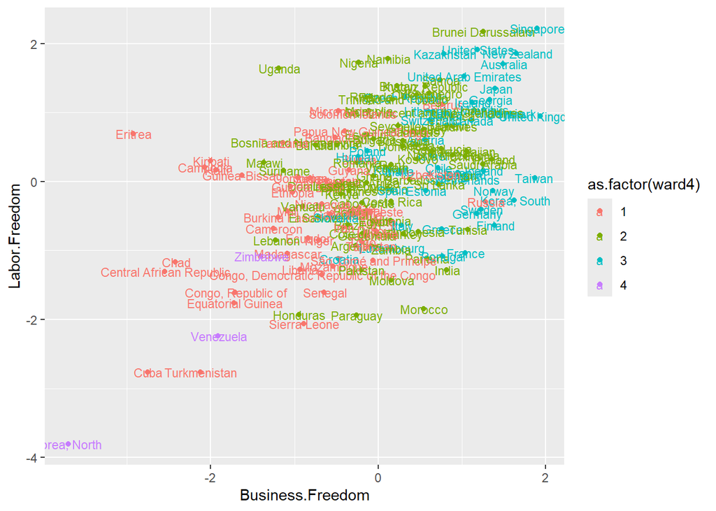

```r
ggplot(econ_st,
       aes(x = Business.Freedom, y = Labor.Freedom,
           label = Country.Name,
           colour = as.factor(ward4))) +
   geom_point() +
   geom_text(size = 3, nudge_x = 0.01)
```

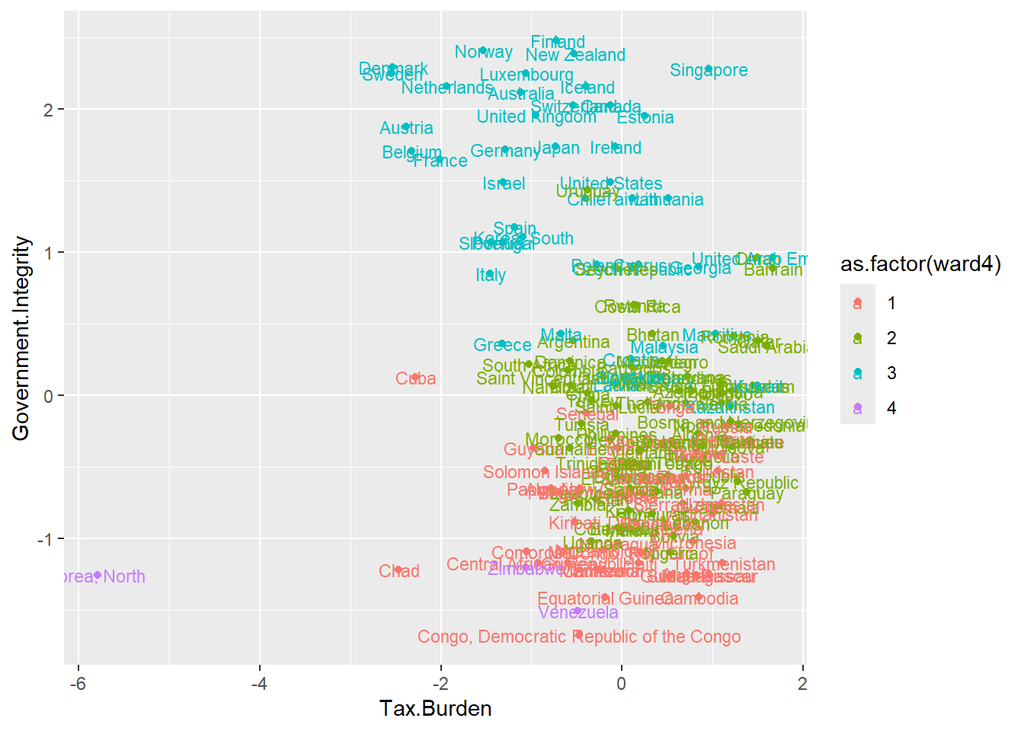

```r
ggplot(econ_st,
       aes(x = Tax.Burden, y = Government.Integrity,
           label = Country.Name,
           colour = as.factor(ward4))) +
   geom_point() +
   geom_text(size = 3, nudge_x = 0.01)
```

Samuti saame visualiseerida, kuidas tekkinud grupid eristuvad üksteisest klasterduse aluseks olevate tunnuste poolest. Esitame nt klasterduse aluseks olevate tunnuste keskmised klastrites.

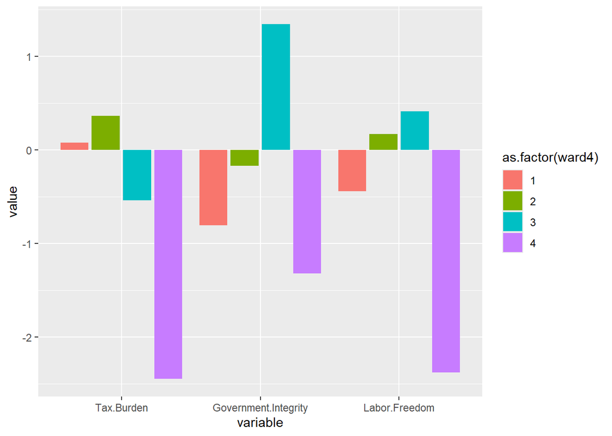

```r
klast_keskm <- econ_st %>%
  group_by(ward4) %>%
  summarise(Tax.Burden = mean(Tax.Burden),
            Government.Integrity = mean(Government.Integrity),
            Labor.Freedom = mean(Labor.Freedom)) %>%
  as.data.frame()

klast_keskm <- melt(klast_keskm, id.vars = "ward4",
                    measure.vars = c("Tax.Burden", "Government.Integrity", "Labor.Freedom"))

ggplot() +
  geom_col(data = klast_keskm,
           aes(x = variable, y = value, fill = as.factor(ward4)),
           position = "dodge2")
```

Kõik tunnused joonisel.

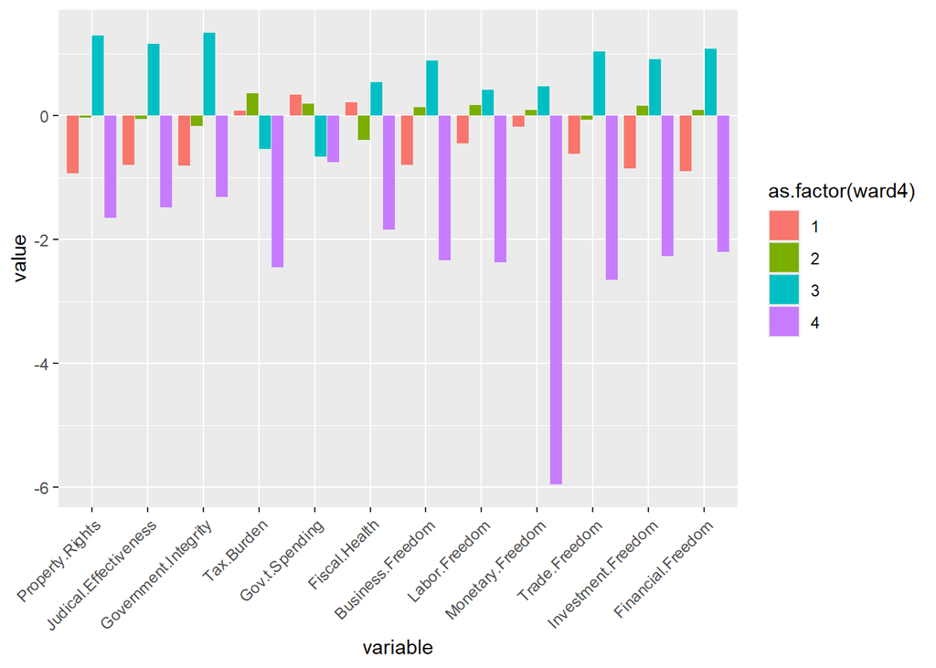

```r
averages <- econ_st %>%
  group_by(ward4) %>%
  summarise(across(names(econ_st)[6:17], mean, na.rm = TRUE)) %>%
  as.data.frame()

averages <- melt(averages, id.vars = "ward4",
                    measure.vars = names(averages)[2:13])

ggplot() +
  geom_col(data = averages,
           aes(x = variable, y = value, fill = as.factor(ward4)),
           position = "dodge2") +
  theme(axis.text.x = element_text(angle = 45, hjust = 1))
```

## 6. Võimalusi klasterduspuude visualiseerimiseks

```r
hclust_ward <- hclust(d, method = "ward.D2")
```

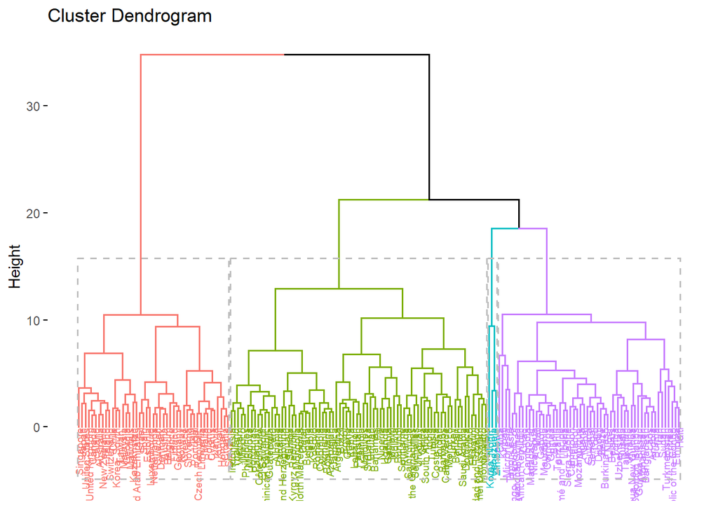

```r
fviz_dend(hclust_ward, # clustering result
          k = 4, # cluster number
          cex = 0.5,
          color_labels_by_k = TRUE,
          rect = TRUE )
```

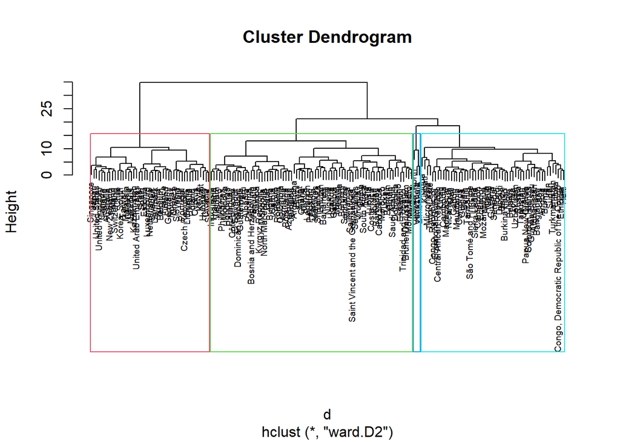

```r
plot(hclust_ward, cex = 0.6)
rect.hclust(hclust_ward, k = 4, border = 2:5)
```

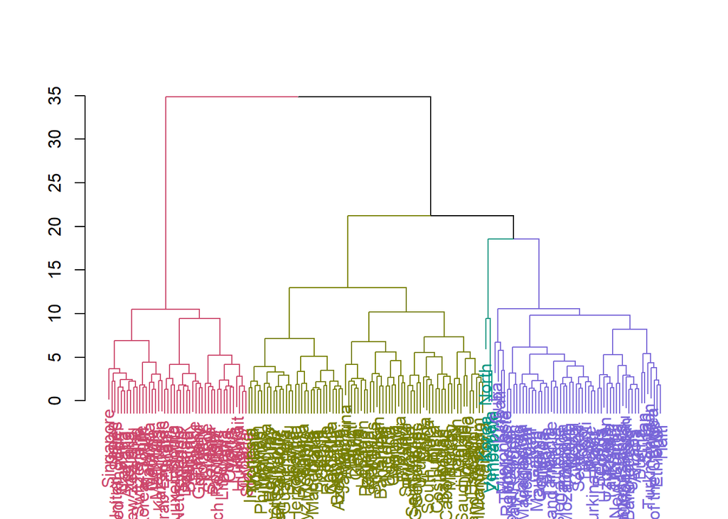

```r
dend <- hclust_ward %>%
  as.dendrogram %>%
  hang.dendrogram

dend %>%
  color_branches(k=4) %>%
  color_labels(k=4) %>%
  plot
```

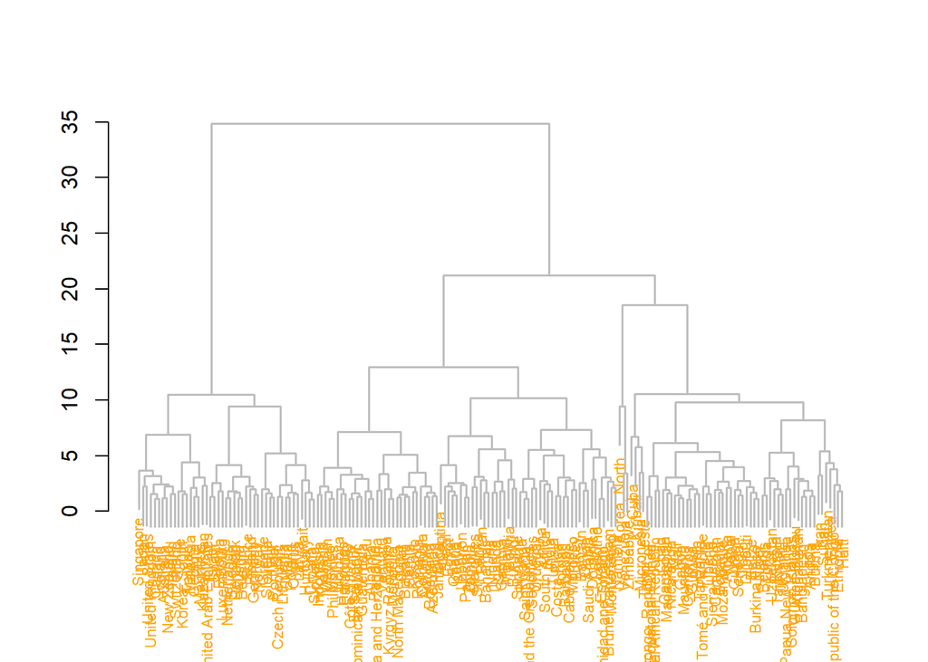

```r
dend %>%
  # Custom branches
  set("branches_col", "grey") %>% set("branches_lwd", 1.8) %>%
  # Custom labels
  set("labels_col", "orange") %>% set("labels_cex", 0.7) %>%
  plot()
```

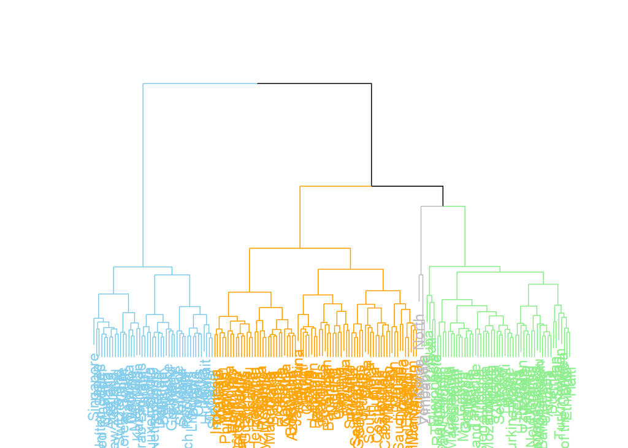

```r
# Color in function of the cluster
#par(mar=c(1,1,1,7))
dend %>%
  set("labels_col",
      value = c("skyblue", "orange", "grey", 'lightgreen'), k=4) %>%
  set("branches_k_color",
      value = c("skyblue", "orange", "grey", 'lightgreen'), k = 4) %>%
  plot(horiz=F, axes=FALSE)
```

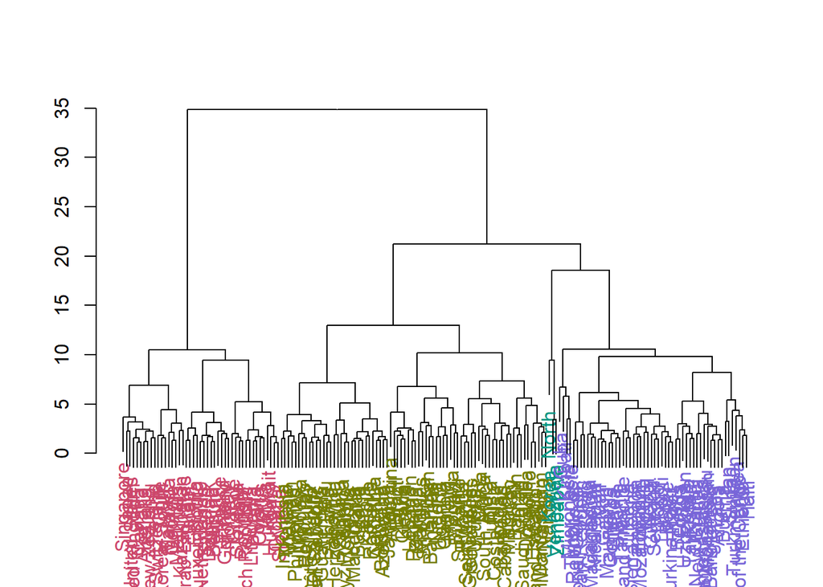

```r
dend %>%
  set("labels_col", k=4) %>%
  plot()
```

Vt veel [siit](http://www.sthda.com/english/wiki/beautiful-dendrogram-visualizations-in-r-5-must-known-methods-unsupervised-machine-learning).

# Harjutus 1

> Eraldage Euroopa riikide andmed. Viige läbi klasterdamine Wardi meetodil. Eelnevalt tunnuseid juba standardiseerisime, aga kas Euroopa riikide omaette uurides oleks standardiseerimist vaja? Kas piisaks enne tehtud standardiseerimisest või oleks mõttekas Euroopa riike standardiseerida kui omaette kogumit? Kas näete klasterstruktuuris mingit loogilist mustrit? Kas Eesti grupikuuluvus tundub loogiline? Milliste riikidega on Eesti kõige sarnasem?

Võtame vaatluse alla Euroopa.

```r
econ_eur <- econ %>%
  subset(Region == "Europe")
```

Veendume, et Euroopa riikide eraldamine töötas.

```r
econ_eur$Country.Name
```

```
##  [1] "Albania"                "Armenia"                "Austria"
##  [4] "Azerbaijan"             "Belarus"                "Belgium"
##  [7] "Bosnia and Herzegovina" "Bulgaria"               "Croatia"
## [10] "Cyprus"                 "Czech Republic"         "Denmark"
## [13] "Estonia"                "Finland"                "France"
## [16] "Georgia"                "Germany"                "Greece"
## [19] "Hungary"                "Iceland"                "Ireland"
## [22] "Italy"                  "Kosovo"                 "Latvia"
## [25] "Lithuania"              "Luxembourg"             "North Macedonia"
## [28] "Malta"                  "Moldova"                "Montenegro"
## [31] "Netherlands"            "Norway"                 "Poland"
## [34] "Portugal"               "Romania"                "Russia"
## [37] "Serbia"                 "Slovakia"               "Slovenia"
## [40] "Spain"                  "Sweden"                 "Switzerland"
## [43] "Turkey"                 "Ukraine"                "United Kingdom"
```

Kas Euroopa riikide omaette uurides oleks standardiseerimist vaja? Vaatame tunnuste jaotusparameetreid.

```r
psych::describe(econ_eur[6:17])
```

```
##                       vars  n  mean    sd median trimmed   mad  min  max range
## Property.Rights          1 45 71.55 12.86   74.1   72.20 16.75 44.1 91.9  47.8
## Judical.Effectiveness    2 45 60.02 15.82   57.9   60.41 18.24 22.8 86.9  64.1
## Government.Integrity     3 45 64.36 19.43   64.4   63.79 26.09 37.9 97.2  59.3
## Tax.Burden               4 45 74.20 15.94   76.7   75.19 19.72 43.6 94.9  51.3
## Gov.t.Spending           5 45 50.06 18.40   49.5   50.71 22.24  6.3 81.3  75.0
## Fiscal.Health            6 45 88.95 11.74   93.1   90.71  7.41 37.2 99.6  62.4
## Business.Freedom         7 45 73.49  9.78   73.6   73.86 10.82 48.2 94.4  46.2
## Labor.Freedom            8 45 61.34 10.71   61.8   61.64 14.23 39.2 78.0  38.8
## Monetary.Freedom         9 45 78.97  5.03   79.7   79.58  4.15 65.4 85.4  20.0
## Trade.Freedom           10 45 81.82  4.37   84.0   82.54  0.00 68.0 86.8  18.8
## Investment.Freedom      11 45 73.89 14.57   75.0   75.95  7.41 30.0 95.0  65.0
## Financial.Freedom       12 45 62.67 14.98   70.0   64.32 14.83 20.0 90.0  70.0
##                        skew kurtosis   se
## Property.Rights       -0.32    -1.03 1.92
## Judical.Effectiveness -0.19    -0.72 2.36
## Government.Integrity   0.24    -1.49 2.90
## Tax.Burden            -0.37    -1.13 2.38
## Gov.t.Spending        -0.28    -0.66 2.74
## Fiscal.Health         -2.10     6.05 1.75
## Business.Freedom      -0.33    -0.35 1.46
## Labor.Freedom         -0.17    -1.11 1.60
## Monetary.Freedom      -1.03     0.62 0.75
## Trade.Freedom         -1.57     1.60 0.65
## Investment.Freedom    -1.45     2.24 2.17
## Financial.Freedom     -0.88     0.59 2.23
```

Siit ilmneb, et kuigi kõik tunnused saavad põhimõtteliselt varieeruda nullist sajani, on tegelik varieeruvus väga erinev (vt miinimum- ja maksimumväärtusi ja haaret).

Tunnused võiks standardiseerida - kas piisab eelnevalt tehtud standardiseerimisest, mis oli tehtud kõigi riikide väärtusi antud tunnustes aluseks võttes? Pigem mitte, sest võrreldes teiste riikidega on Euroopa riikide väärtused koondunud 0-100 skaalal kitsamale alale (riigid on omavahel suhteliselt sarnased).

Kui võtaksime Euroopa riikide analüüsimisel aluseks eelnevalt tehtud standardiseerimise, ei oleks ilmselt võimalik riikidevahelisi erinevusi nii hästi arvesse võtta, seetõttu võiks teha siin Euroopa riikide andmetele eraldi standardiseerimise (st arvutame igas tunnuses iga riigi puhul tema väärtuse erinevuse tunnuse Euroopa keskmisest ja jagame selle läbi tunnuse Euroopa standardhälbega, mitte ei arvesta kogu maailma keskmist ja standardhälvet).

Standardiseerime

```r
econ_eur_st <- econ_eur
econ_eur_st[6:17] <- scale(econ_eur[6:17])
```

Arvutame kaugused.

```r
rownames(econ_eur_st) <- econ_eur_st$Country.Name
d_eur <- stats::dist(econ_eur_st[6:17])
```

Teeme klasterduse Wardi meetodil.

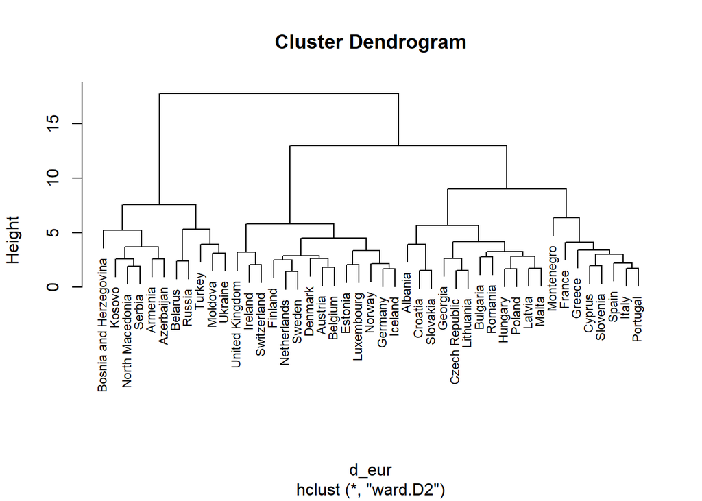

```r
hclust(d_eur, method = "ward.D2") %>%
  plot(cex = 0.75)
```

Tundub, et saame eristada viis distinktiivset klastrit. Kas näete klasterstruktuuris mingit loogilist mustrit? Kas Eesti grupikuuluvus tundub loogiline? Milliste riikidega on Eesti kõige sarnasem?

Alljärgnevalt on ära toodud mõned käsud, mis võiksid aidata klastreid lähemalt uurida.

Lisame andmestikku klastrikuuluvuse tunnuse.

```r
econ_eur_st$ward5 <- hclust(d_eur, method = "ward.D2") %>%
  cutree(5)
```

Jooniselt nägime, millised riigid eraldi klastritesse koonduvad, vaatame ka, millise numbriga klastris vastavad riigid on.

```r
econ_eur_st %>%
  arrange(ward5) %>%
  select(ward5)
```

```
##                        ward5
## Albania                    1
## Bulgaria                   1
## Croatia                    1
## Czech Republic             1
## Georgia                    1
## Hungary                    1
## Latvia                     1
## Lithuania                  1
## Malta                      1
## Poland                     1
## Romania                    1
## Slovakia                   1
## Armenia                    2
## Azerbaijan                 2
## Bosnia and Herzegovina     2
## Kosovo                     2
## North Macedonia            2
## Serbia                     2
## Austria                    3
## Belgium                    3
## Denmark                    3
## Estonia                    3
## Finland                    3
## Germany                    3
## Iceland                    3
## Ireland                    3
## Luxembourg                 3
## Netherlands                3
## Norway                     3
## Sweden                     3
## Switzerland                3
## United Kingdom             3
## Belarus                    4
## Moldova                    4
## Russia                     4
## Turkey                     4
## Ukraine                    4
## Cyprus                     5
## France                     5
## Greece                     5
## Italy                      5
## Montenegro                 5
## Portugal                   5
## Slovenia                   5
## Spain                      5
```

Milline on nende riikide majandusvabadus kokkuvõtliku indeksi järgi keskmiselt?

```r
econ_eur_st %>%
  group_by(ward5) %>%
  summarise(mean = mean(X2021.Score), rank_med = median(Region.Rank))
```

```
## # A tibble: 5 × 3
##   ward5  mean rank_med
##   <int> <dbl>    <dbl>
## 1     1  70.2     23
## 2     2  67.9     28.5
## 3     3  76.3      9.5
## 4     4  61.0     42
## 5     5  66.5     31.5
```

# Harjutus 2

> Jätkame Euroopa andmetega, võtame aluseks viiese klasterduse. Kas klasterdus andis õieti midagi juurde juba koostatud indeksile? Mille alusel saaks seda hinnata?

Siin oleks kõige lihtsam vaadata, kui järjestame riigid majandusvabaduse indeksi alusel, siis kas samades klastrites olevad riigid on järjestikku või esinevad nad järjekorras mingil määral läbisegi. Esimesel juhul annaks klasterdus sama tulemuse, mis majandusvabaduse indeks, teisel juhul võib klasterdus viidata mingile lisainfole selle kohta, kas mingid riigid on teatud dimensioonides sarnasemad, olgugi et keskmiselt võivad nad indeksi alusel paista samal majandusvabaduse tasemel olevat.

Tabelist võiks eelnimetatud küsimusele üsna lihtsalt vastuse saada.

```r
econ_eur_st %>%
  arrange(desc(X2021.Score)) %>%
  select(Region.Rank, X2021.Score, ward5) %>%
  kable(caption = "Tabel 2. Euroopa riigid majandusvabaduse indeksi ja klastrikuuluvuse järgi.") %>%
  kable_styling("striped") %>%
  scroll_box(height = "500px", width = "100%")
```

Tabel 2. Euroopa riigid majandusvabaduse indeksi ja klastrikuuluvuse järgi.

|  | Region.Rank | X2021.Score | ward5 |
| --- | --- | --- | --- |
| Switzerland | 1 | 81.9 | 3 |
| Ireland | 2 | 81.4 | 3 |
| United Kingdom | 3 | 78.4 | 3 |
| Estonia | 4 | 78.2 | 3 |
| Denmark | 5 | 77.8 | 3 |
| Iceland | 6 | 77.4 | 3 |
| Georgia | 7 | 77.2 | 1 |
| Lithuania | 8 | 76.9 | 1 |
| Netherlands | 9 | 76.8 | 3 |
| Finland | 10 | 76.1 | 3 |
| Luxembourg | 11 | 76.0 | 3 |
| Sweden | 12 | 74.7 | 3 |
| Austria | 13 | 73.9 | 3 |
| Czech Republic | 14 | 73.8 | 1 |
| Norway | 15 | 73.4 | 3 |
| Germany | 16 | 72.5 | 3 |
| Latvia | 17 | 72.3 | 1 |
| Armenia | 18 | 71.9 | 2 |
| Cyprus | 19 | 71.4 | 5 |
| Bulgaria | 20 | 70.4 | 1 |
| Malta | 21 | 70.2 | 1 |
| Azerbaijan | 23 | 70.1 | 2 |
| Belgium | 22 | 70.1 | 3 |
| Spain | 24 | 69.9 | 5 |
| Poland | 25 | 69.7 | 1 |
| Romania | 26 | 69.5 | 1 |
| North Macedonia | 27 | 68.6 | 2 |
| Slovenia | 28 | 68.3 | 5 |
| Portugal | 29 | 67.5 | 5 |
| Hungary | 31 | 67.2 | 1 |
| Serbia | 30 | 67.2 | 2 |
| Kosovo | 32 | 66.5 | 2 |
| Slovakia | 33 | 66.3 | 1 |
| France | 34 | 65.7 | 5 |
| Albania | 35 | 65.2 | 1 |
| Italy | 36 | 64.9 | 5 |
| Turkey | 37 | 64.0 | 4 |
| Croatia | 38 | 63.6 | 1 |
| Montenegro | 39 | 63.4 | 5 |
| Bosnia and Herzegovina | 40 | 62.9 | 2 |
| Moldova | 41 | 62.5 | 4 |
| Russia | 42 | 61.5 | 4 |
| Belarus | 43 | 61.0 | 4 |
| Greece | 44 | 60.9 | 5 |
| Ukraine | 45 | 56.2 | 4 |

Kui tabelile lisada tingimuslik vormindamine, võib riikide koondumist tabelis pareminigi märgata.

```r
econ_eur_st <- econ_eur_st %>%
  arrange(desc(X2021.Score))

econ_eur_st %>%
  select(Region.Rank, X2021.Score, ward5) %>%
  kable(caption = "Tabel 3. Euroopa riigid majandusvabaduse indeksi ja klastrikuuluvuse järgi, lisatud tingimuslik vormindamine klastrikuuluvuse alusel.") %>%
  kable_styling("striped") %>%
  column_spec(4, color = "white", background = spec_color(econ_eur_st$ward5, option = "magma", begin = 0.3, end = 0.7)) %>%
  scroll_box(height = "500px", width = "100%")
```

Tabel 3. Euroopa riigid majandusvabaduse indeksi ja klastrikuuluvuse järgi, lisatud tingimuslik vormindamine klastrikuuluvuse alusel.

|  | Region.Rank | X2021.Score | ward5 |
| --- | --- | --- | --- |
| Switzerland | 1 | 81.9 | 3 |
| Ireland | 2 | 81.4 | 3 |
| United Kingdom | 3 | 78.4 | 3 |
| Estonia | 4 | 78.2 | 3 |
| Denmark | 5 | 77.8 | 3 |
| Iceland | 6 | 77.4 | 3 |
| Georgia | 7 | 77.2 | 1 |
| Lithuania | 8 | 76.9 | 1 |
| Netherlands | 9 | 76.8 | 3 |
| Finland | 10 | 76.1 | 3 |
| Luxembourg | 11 | 76.0 | 3 |
| Sweden | 12 | 74.7 | 3 |
| Austria | 13 | 73.9 | 3 |
| Czech Republic | 14 | 73.8 | 1 |
| Norway | 15 | 73.4 | 3 |
| Germany | 16 | 72.5 | 3 |
| Latvia | 17 | 72.3 | 1 |
| Armenia | 18 | 71.9 | 2 |
| Cyprus | 19 | 71.4 | 5 |
| Bulgaria | 20 | 70.4 | 1 |
| Malta | 21 | 70.2 | 1 |
| Azerbaijan | 23 | 70.1 | 2 |
| Belgium | 22 | 70.1 | 3 |
| Spain | 24 | 69.9 | 5 |
| Poland | 25 | 69.7 | 1 |
| Romania | 26 | 69.5 | 1 |
| North Macedonia | 27 | 68.6 | 2 |
| Slovenia | 28 | 68.3 | 5 |
| Portugal | 29 | 67.5 | 5 |
| Hungary | 31 | 67.2 | 1 |
| Serbia | 30 | 67.2 | 2 |
| Kosovo | 32 | 66.5 | 2 |
| Slovakia | 33 | 66.3 | 1 |
| France | 34 | 65.7 | 5 |
| Albania | 35 | 65.2 | 1 |
| Italy | 36 | 64.9 | 5 |
| Turkey | 37 | 64.0 | 4 |
| Croatia | 38 | 63.6 | 1 |
| Montenegro | 39 | 63.4 | 5 |
| Bosnia and Herzegovina | 40 | 62.9 | 2 |
| Moldova | 41 | 62.5 | 4 |
| Russia | 42 | 61.5 | 4 |
| Belarus | 43 | 61.0 | 4 |
| Greece | 44 | 60.9 | 5 |
| Ukraine | 45 | 56.2 | 4 |

# Harjutus 3

> Jagades riigid viiese klasterduse alusel, uurige lähemalt gruppi, kuhu kuulub Eesti, st uurige 12 tunnuse väärtusi nende riikide lõikes. Mille poolest sarnaneb Eesti enamikule oma grupi riikidele kõige rohkem? Kus on suurimad erinevused? Eestile sarnaseim riik peaks klasterduse järgi olema Luksemburg - milliste tunnuste põhjal on sarnasus suurim, kas mingite tunnuste poolest leidub olulisi erinevusi?

Uurime lähemalt Eestit võrdluses oma klastriliikmetega. Teeme 12 tunnusega joonise, kus riigid oleks järjestatud koondindeksi väärtuse alusel ning Eesti ja Luksemburg kui Eestile sarnaseim riik oleks kergesti eristatavad.

Eraldame vajalikud andmed.

```r
clust_ee <- econ_eur_st %>%
  subset(ward5 == 3) %>%
  select(1, 5:17)

clust_ee
```

```
##                  Country.Name X2021.Score Property.Rights Judical.Effectiveness
## Switzerland       Switzerland        81.9       1.0768987             1.4018946
## Ireland               Ireland        81.4       1.1235551             0.7825443
## United Kingdom United Kingdom        78.4       1.2479722             1.0543000
## Estonia               Estonia        78.2       0.7969603             1.3134160
## Denmark               Denmark        77.8       1.1779876             1.6989300
## Iceland               Iceland        77.4       1.2013158             0.7951841
## Netherlands       Netherlands        76.8       1.3490610             0.8078239
## Finland               Finland        76.1       1.5823430             1.4018946
## Luxembourg         Luxembourg        76.0       1.1002269             1.1111791
## Sweden                 Sweden        74.7       1.1702115             1.2059777
## Austria               Austria        73.9       1.1857636             1.4840533
## Norway                 Norway        73.4       0.8436167             1.6610106
## Germany               Germany        72.5       0.5636784             0.6182268
## Belgium               Belgium        70.1       0.9680338             0.6435064
##                Government.Integrity Tax.Burden Gov.t.Spending Fiscal.Health
## Switzerland               1.2114836 -0.2380596      0.9535199    0.67671087
## Ireland                   0.9078407  0.1508082      1.6874149    0.35311590
## United Kingdom            1.1394328 -0.5830230      0.2576787   -0.99235788
## Estonia                   1.1342863  0.4267789      0.2359337    0.90663360
## Denmark                   1.4945405 -1.9127000     -1.4656155    0.78741440
## Iceland                   1.3504388 -0.1126183     -0.2098396    0.73632046
## Netherlands               1.3504388 -1.4109351     -0.1282957    0.54046036
## Finland                   1.6901071 -0.3885890     -1.9440063    0.20834974
## Luxembourg                1.4482221 -0.6771039     -0.2098396    0.85553966
## Sweden                    1.4482221 -1.9189720     -1.1176949    0.73632046
## Austria                   1.0519425 -1.7872587     -1.1394400    0.08913054
## Norway                    1.6180563 -1.0722437     -1.3460178    0.65116389
## Germany                   0.8821083 -0.8652657     -0.5305789    0.32756893
## Belgium                   0.8718153 -1.7370823     -1.7211197   -0.87313868
##                Business.Freedom Labor.Freedom Monetary.Freedom Trade.Freedom
## Switzerland          0.01090211    1.04208829        1.2785471     0.9559602
## Ireland              0.81833946    1.37824581        1.0796031     0.4988060
## United Kingdom       2.13681311    1.10745225        0.4031933     0.4988060
## Estonia             -0.08108443   -0.33055489        0.1445660     0.4988060
## Denmark              1.56445246    1.16347850        1.0994975     0.4988060
## Iceland              1.03297470    0.06162888        0.0848828     1.1388219
## Netherlands          0.71613220   -0.11578759        0.2838269     0.4988060
## Finland              1.25783068   -1.01220762        0.8607646     0.4988060
## Luxembourg          -0.75565234   -1.44174222       -0.4920550     0.4988060
## Sweden               0.99209180   -0.69472553        0.5026653     0.4988060
## Austria             -0.09130515    0.65924223        0.5424541     0.4988060
## Norway               1.22716850   -0.33055489       -0.7108934     0.4988060
## Germany              0.91032599   -0.77876491       -0.3527941     0.4988060
## Belgium              0.67524930   -0.02241050        0.6021373     0.4988060
##                Investment.Freedom Financial.Freedom
## Switzerland            0.76244248         1.8240656
## Ireland                1.10554160         0.4893835
## United Kingdom         0.41934336         1.1567246
## Estonia                1.10554160         0.4893835
## Denmark                1.10554160         1.1567246
## Iceland                0.41934336         0.4893835
## Netherlands            1.10554160         1.1567246
## Finland                0.76244248         1.1567246
## Luxembourg             1.44864071         1.1567246
## Sweden                 0.76244248         1.1567246
## Austria                1.10554160         0.4893835
## Norway                 0.07624425        -0.1779576
## Germany                0.41934336         0.4893835
## Belgium                0.76244248         0.4893835
```

Kuigi järjestasime riigid andmestikus eelnevalt ära, reastaks `ggplot` joonisel riigid ikkagi tähestikulises järjekorras, sest lähtub kategoriaalse tunnuse *(factor)* puhul tunnuse kategooriate järjestusest, mis tekstilise tunnuse puhul on tähestikuline. Seetõttu peame tunnuses kategooriate järjestuse eraldi ära muutma. Teeme seda paketi `forcats` funktsiooniga `fct_reorder`, pärast seda eemaldame andmestikust indeksitunnuse, sest jätame joonisele ainult klasterduse aluseks olnud 12 tunnust.

```r
clust_ee$Country.Name <- forcats::fct_reorder(clust_ee$Country.Name,
                                              clust_ee$X2021.Score, max)
clust_ee <- select(clust_ee, !X2021.Score)
clust_ee
```

```
##                  Country.Name Property.Rights Judical.Effectiveness
## Switzerland       Switzerland       1.0768987             1.4018946
## Ireland               Ireland       1.1235551             0.7825443
## United Kingdom United Kingdom       1.2479722             1.0543000
## Estonia               Estonia       0.7969603             1.3134160
## Denmark               Denmark       1.1779876             1.6989300
## Iceland               Iceland       1.2013158             0.7951841
## Netherlands       Netherlands       1.3490610             0.8078239
## Finland               Finland       1.5823430             1.4018946
## Luxembourg         Luxembourg       1.1002269             1.1111791
## Sweden                 Sweden       1.1702115             1.2059777
## Austria               Austria       1.1857636             1.4840533
## Norway                 Norway       0.8436167             1.6610106
## Germany               Germany       0.5636784             0.6182268
## Belgium               Belgium       0.9680338             0.6435064
##                Government.Integrity Tax.Burden Gov.t.Spending Fiscal.Health
## Switzerland               1.2114836 -0.2380596      0.9535199    0.67671087
## Ireland                   0.9078407  0.1508082      1.6874149    0.35311590
## United Kingdom            1.1394328 -0.5830230      0.2576787   -0.99235788
## Estonia                   1.1342863  0.4267789      0.2359337    0.90663360
## Denmark                   1.4945405 -1.9127000     -1.4656155    0.78741440
## Iceland                   1.3504388 -0.1126183     -0.2098396    0.73632046
## Netherlands               1.3504388 -1.4109351     -0.1282957    0.54046036
## Finland                   1.6901071 -0.3885890     -1.9440063    0.20834974
## Luxembourg                1.4482221 -0.6771039     -0.2098396    0.85553966
## Sweden                    1.4482221 -1.9189720     -1.1176949    0.73632046
## Austria                   1.0519425 -1.7872587     -1.1394400    0.08913054
## Norway                    1.6180563 -1.0722437     -1.3460178    0.65116389
## Germany                   0.8821083 -0.8652657     -0.5305789    0.32756893
## Belgium                   0.8718153 -1.7370823     -1.7211197   -0.87313868
##                Business.Freedom Labor.Freedom Monetary.Freedom Trade.Freedom
## Switzerland          0.01090211    1.04208829        1.2785471     0.9559602
## Ireland              0.81833946    1.37824581        1.0796031     0.4988060
## United Kingdom       2.13681311    1.10745225        0.4031933     0.4988060
## Estonia             -0.08108443   -0.33055489        0.1445660     0.4988060
## Denmark              1.56445246    1.16347850        1.0994975     0.4988060
## Iceland              1.03297470    0.06162888        0.0848828     1.1388219
## Netherlands          0.71613220   -0.11578759        0.2838269     0.4988060
## Finland              1.25783068   -1.01220762        0.8607646     0.4988060
## Luxembourg          -0.75565234   -1.44174222       -0.4920550     0.4988060
## Sweden               0.99209180   -0.69472553        0.5026653     0.4988060
## Austria             -0.09130515    0.65924223        0.5424541     0.4988060
## Norway               1.22716850   -0.33055489       -0.7108934     0.4988060
## Germany              0.91032599   -0.77876491       -0.3527941     0.4988060
## Belgium              0.67524930   -0.02241050        0.6021373     0.4988060
##                Investment.Freedom Financial.Freedom
## Switzerland            0.76244248         1.8240656
## Ireland                1.10554160         0.4893835
## United Kingdom         0.41934336         1.1567246
## Estonia                1.10554160         0.4893835
## Denmark                1.10554160         1.1567246
## Iceland                0.41934336         0.4893835
## Netherlands            1.10554160         1.1567246
## Finland                0.76244248         1.1567246
## Luxembourg             1.44864071         1.1567246
## Sweden                 0.76244248         1.1567246
## Austria                1.10554160         0.4893835
## Norway                 0.07624425        -0.1779576
## Germany                0.41934336         0.4893835
## Belgium                0.76244248         0.4893835
```

Plaanitava joonise tegemiseks on vaja, et andmed oleksid pikkformaadis (seni on olnud andmed laiformaadis). Kasutame andmete pikkformaati konverteerimiseks paketti `reshape2`, funktsiooni `melt`.

```r
clust_ee_long <- melt(clust_ee, id=c("Country.Name"))
clust_ee_long
```

```
##       Country.Name              variable       value
## 1      Switzerland       Property.Rights  1.07689871
## 2          Ireland       Property.Rights  1.12355510
## 3   United Kingdom       Property.Rights  1.24797216
## 4          Estonia       Property.Rights  0.79696034
## 5          Denmark       Property.Rights  1.17798756
## 6          Iceland       Property.Rights  1.20131576
## 7      Netherlands       Property.Rights  1.34906101
## 8          Finland       Property.Rights  1.58234298
## 9       Luxembourg       Property.Rights  1.10022691
## 10          Sweden       Property.Rights  1.17021150
## 11         Austria       Property.Rights  1.18576363
## 12          Norway       Property.Rights  0.84361674
## 13         Germany       Property.Rights  0.56367837
## 14         Belgium       Property.Rights  0.96803379
```

[output cut: 154 more lines]

Teeme uue tunnuse, mis võimaldab Eesti ja Luksemburgi tulbad joonisel esitada muu värviga.

```r
clust_ee_long <- clust_ee_long %>%
  mutate(legend_colour = ifelse(Country.Name == "Estonia", "Estonia",
                                ifelse(Country.Name == "Luxembourg", "Luxembourg", "Other")))

clust_ee_long
```

```
##       Country.Name              variable       value legend_colour
## 1      Switzerland       Property.Rights  1.07689871         Other
## 2          Ireland       Property.Rights  1.12355510         Other
## 3   United Kingdom       Property.Rights  1.24797216         Other
## 4          Estonia       Property.Rights  0.79696034       Estonia
## 5          Denmark       Property.Rights  1.17798756         Other
## 6          Iceland       Property.Rights  1.20131576         Other
## 7      Netherlands       Property.Rights  1.34906101         Other
## 8          Finland       Property.Rights  1.58234298         Other
## 9       Luxembourg       Property.Rights  1.10022691    Luxembourg
## 10          Sweden       Property.Rights  1.17021150         Other
## 11         Austria       Property.Rights  1.18576363         Other
## 12          Norway       Property.Rights  0.84361674         Other
## 13         Germany       Property.Rights  0.56367837         Other
## 14         Belgium       Property.Rights  0.96803379         Other
```

[output cut: 154 more lines]

Teeme joonise, kus on 12 tulpdiagrammi iga tunnuse kohta eraldi.

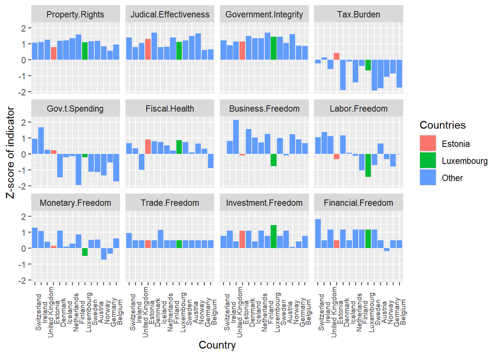

Joonis 5. Klasterduse aluseks olnud tunnuste väärtused riikides, mis kuuluvad Eestiga samasse klastrisse.

```r
ggplot(clust_ee_long, aes(x = Country.Name, y = value, fill = legend_colour)) +
  geom_bar(stat = "identity", position = "dodge") +
  facet_wrap(variable ~ .) +
  theme(axis.text.x = element_text(angle = 90, size = 7)) +
  theme(legend.position = "right") +
  scale_fill_discrete(name = "Countries") +
  scale_x_discrete(limits = rev) +
  xlab("Country") +
  ylab("Z-score of indicator")
```

Püüdke joonise abil harjutuses püstitatud küsimustele vastused leida.